# R help and debugging

Christine Stawitz

ECS Federal in support of NOAA Fisheries

March 24, 2020

## About me

- Undergraduate degree in Systems Engineering, CS
- Microsoft
- Phd Quantitative Ecology
- Now: creating generalized tools for fisheries modeling at ECS Federal for NOAA

## Not: CS training

- More elegant code
- Code is less buggy

## Yes: CS training

- Constantly foiled by weak typing
- Really good at Googling through documentation
- Very reliant on debugging

## Outline

- Documentation types and uses
- Diagnosing problems with inputs & environment
- Debugging to find code problems

## Documentation

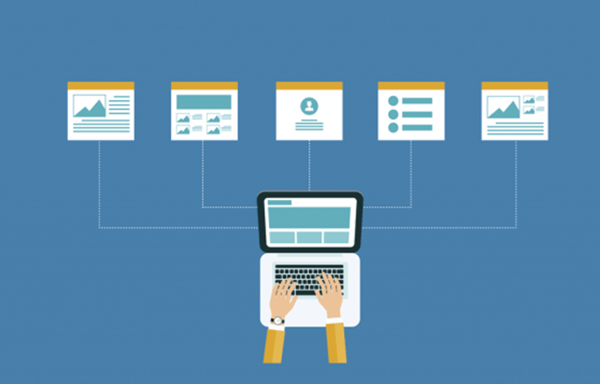

## Types

- User guides, vignettes, tutorials
- Examples
- Function reference

## User guides, tutorials, and vignettes

Best when starting to use a new package for the first time. Step-by-step reference with guidance on syntax, dependencies, and workflow.

## User guides, tutorials, and vignettes

## Examples

Best for understanding syntax and testing environment.

```r
tibble(vec_col = 1:10) %>%
  mutate(vec_sum = sum(vec_col))
```

## Function reference

- a brief description of the function/class/dataset
- a description of all of the function arguments, including what type of object (integer, string, etc.) each argument is, what the argument is named, acceptable values for the argument (if it must match a specific input), and the default value for the argument
- a description of the object(s) returned from the function
- an example detailing syntax of how the function is used

## Finding errors

- Environment errors
- Input errors
- Code errors & debugging

## Environment errors

```r
tibble(vec_col = 1:10) %>%
  mutate(vec_sum = sum(vec_col))
```

```
## Error in tibble(vec_col = 1:10) %>% mutate(vec_sum = sum(vec_col)): could not find function "%>%"
```

## Environment errors

```r
require(dplyr)
tibble(vec_col = 1:10) %>%
  mutate(vec_sum = sum(vec_col))
```

```
## # A tibble: 10 x 2
##    vec_col vec_sum
##      <int>   <int>
##  1       1      55
##  2       2      55
##  3       3      55
##  4       4      55
##  5       5      55
##  6       6      55
##  7       7      55
##  8       8      55
##  9       9      55
## 10      10      55
```

- Restart R
- Use package examples

## Input errors

```r
input_data <- list(c(1, 5, 7),
                       5,
                       c(10, 10, 11))
tibble(list_col = input_data) %>%
  mutate(list_sum = sum(list_col))
```

```
## Error in sum(list_col): invalid 'type' (list) of argument
```

```r
str(input_data)
```

```
## List of 3
##  $ : num [1:3] 1 5 7
##  $ : num 5
##  $ : num [1:3] 10 10 11
```

- Cross-reference function documentation
- `str()` to see input structure

## Debugging

[RStudio::conf talk](https://resources.rstudio.com/rstudio-conf-2020/object-of-type-closure-is-not-subsettable-jenny-bryan)

## Restart `R` - still useful!

```r
foo <- c(1,2,3)

sum_the_cols <- function(dat){
tibble(list_col = input_data) %>%
  mutate(list_sum = sum(list_col))
}

sum_the_cols(foo)
```

```
## Error in sum(list_col): invalid 'type' (list) of argument
```

## Restart `R` - still useful!

```r
rm(input_data)

sum_the_cols(foo)
```

```
## Error in eval_tidy(xs[[i]], unique_output): object 'input_data' not found
```

## `debugonce()`

```r
#Use it for other people's code
debugonce(mutate)
foo <- c(1,2,3)

#use it for your own
sum_the_cols <- function(dat){
tibble(list_col = dat) %>%
  mutate(list_sum = sum(list_col))
}

debugonce(sum_the_cols)
sum_the_cols(foo)
```

## `browser()`

```r
input_data <- list(c(1, 5, 7),
                       5,
                       c(10, 10, 11))
foo <- 1:10

sum_the_cols <- function(dat){
  browser()

tibble(list_col = input_data) %>%
  mutate(list_sum = sum(list_col))
}

sum_the_cols(input_data)
```

```
## Called from: sum_the_cols(input_data)
## debug at <text>#9: tibble(list_col = input_data) %>% mutate(list_sum = sum(list_col))
```

```
## Error in sum(list_col): invalid 'type' (list) of argument
```

## Preventing future bugs

```r
foo <- c(1,2,3)

sum_the_cols <- function(dat){
  if(is.list(dat)){
    stop("Error: mutate doesn't work on list inputs!")
  }
  tibble(list_col = dat) %>%
    mutate(list_sum = sum(list_col))
}

sum_the_cols(input_data)
```

```
## Error in sum_the_cols(input_data): Error: mutate doesn't work on list inputs!
```

## Summary

- Use user guides & vignettes before you start coding
- Start with simple checks: environment errors by reloading and testing examples
- Next, check your inputs against the function reference
- Debug!
- If it’s someone else’s package, create a `reprex`
- If it’s your own code, use `stop()` to prevent the next time!

## thanks!

[Source for example code](http://www.rebeccabarter.com/blog/2019-08-19_purrr/)